# PL SC 309: Making Predictions

## **Why Should I Do It?**

When we run a regression, the regression output tells us the direction of the relationship between our independent variables and our dependent variable and also whether or not there is a reliable (statistically significant) relationship between the independent variables and the dependent variable. However, we oftentimes want to know how we should expect our dependent variable to change as our independent variable of interest changes. The best way to do this is to make a *prediction*.

## **How Do I Do It?**

For this example, we will use the ANES dataset and the Supreme Court feeling thermometer as our dependent variable. Let’s start by loading in that data.

```r
library(foreign)
setwd("~/Dropbox/309/Data/2012ANES")
anes <- read.dta("2012ANES.dta",convert.factors=FALSE)
```

*Note that anes is what I have chosen to call my data object. You can call it anything you want. I chose anes because this data is from the American National Election Studies (the ANES)*

We will begin by running a simple, one-variable regression with the Obama Feeling Thermometer as our independent variable:

```r
model <- lm(supCtFT~obamaFT,data=anes)
summary(model)
```

```
##
## Call:
## lm(formula = supCtFT ~ obamaFT, data = anes)
##
## Residuals:
##     Min      1Q  Median      3Q     Max
## -64.406 -11.787  -0.914  12.578  53.054
##
## Coefficients:
##             Estimate Std. Error t value Pr(>|t|)
## (Intercept)  46.9461     0.5239   89.61   <2e-16 ***
## obamaFT       0.1746     0.0075   23.28   <2e-16 ***
## ---
## Signif. codes:  0 '***' 0.001 '**' 0.01 '*' 0.05 '.' 0.1 ' ' 1
##
## Residual standard error: 19.13 on 5427 degrees of freedom
##   (485 observations deleted due to missingness)
## Multiple R-squared:  0.0908, Adjusted R-squared:  0.09063
## F-statistic:   542 on 1 and 5427 DF,  p-value: < 2.2e-16
```

Our regression has an alpha-hat of 46.95. This means that, when the Obama Feeling Thermometer is 0, our best guess for the Supreme Court Feeling Thermometer (our dependent variable) is 46.95. The beta-hat of 0.17 means that, for each one-point increase in the Obama Feeling Thermometer, we expect the Supreme Court Feeling Thermometer to increase by 0.17 points. The R-Squared value of 0.09 means that our model explains 9% of the variation in the dependent variable (Supreme Court Feeling Thermometer).

Let’s say we want to know what someone’s expected Supreme Court Feeling Thermometer value would be if they had an Obama Feeling Thermometer value of 10. We know how to calculate this by hand:

Y-hat = alpha-hat + beta-hat * 10  
Y-hat = 46.95 + 0.17 * 10  
Y-hat = 48.7

So, we would expect that person to have a Supreme Court Feeling Thermometer value of 48.65.

The `predict` command in R can do the math for us. It is very easy to use:

```r
predict(model,newdata=data.frame(obamaFT=10))
```

```
##        1
## 48.69214
```

This is the same value we just calculated!

Let’s break this code down. The command asks us to *predict* from our linear regression named *model* (which is what we called it when we ran the `lm()` command above). Then, we gave the command the independent variable value (*newdata*) in a *data.frame* that we would like a prediction for.

You can also add a confidence interval around your prediction:

```r
  predict(model,newdata=data.frame(obamaFT=10),interval="predict")
```

```
##        fit      lwr      upr
## 1 48.69214 11.17381 86.21047
```

## **How Does This Work for Multiple Regression?**

It is exactly the same! The only difference is that your predict command **must have a value for every independent variable in the model.** You should pick mean, median, or modal values for those variables. Here’s an example:

```r
model2 <- lm(supCtFT~obamaFT+democrat+republican+gender+black+income+education,data=anes)
summary(model2)
```

```
##
## Call:
## lm(formula = supCtFT ~ obamaFT + democrat + republican + gender +
##     black + income + education, data = anes)
##
## Residuals:
##     Min      1Q  Median      3Q     Max
## -69.736 -11.287  -0.335  12.103  57.839
##
## Coefficients:
##             Estimate Std. Error t value Pr(>|t|)
## (Intercept) 42.16320    1.11393  37.851  < 2e-16 ***
## obamaFT      0.20528    0.01111  18.474  < 2e-16 ***
## democrat    -0.32618    0.72245  -0.451  0.65166
## republican   5.26657    0.78521   6.707 2.21e-11 ***
## gender       0.45914    0.55720   0.824  0.40997
## black        1.68333    0.79357   2.121  0.03395 *
## income       0.12016    0.03799   3.163  0.00157 **
## education   -0.12279    0.26205  -0.469  0.63939
## ---
## Signif. codes:  0 '***' 0.001 '**' 0.01 '*' 0.05 '.' 0.1 ' ' 1
##
## Residual standard error: 19.17 on 4844 degrees of freedom
##   (1062 observations deleted due to missingness)
## Multiple R-squared:  0.09903,    Adjusted R-squared:  0.09773
## F-statistic: 76.06 on 7 and 4844 DF,  p-value: < 2.2e-16
```

```r
predict(model2,newdata=data.frame(obamaFT=10,democrat=1,republican=0,gender=0,black=0,income=13,education=3))
```

```
##        1
## 45.08345
```

This tells us that the expected Supreme Court Feeling Thermometer score for a man (`gender=0`) who is not black (`black=0`) and is a democrat (`democrat=1, republican=0`) in the 13th income category (`income=13`) and the third education category (`education=3`) who has an Obama Feeling Thermometer value of 10 (`obamaFT=10`) is 45.08.

**Remember that YOU MUST INCLUDE IN THE `predict()` COMMAND A VALUE FOR EVERY INDEPENDENT VARIABLE!!**

## **How Does This Work for Interactions?**

Exactly the same! Here is an example that uses the Obama Feeling Thermometer as the dependent variable and tests whether the Liberal Feeling Thermometer has a different effect on one’s feeling toward Obama based on whether or not that person is black:

```r
#Run the model
m1 <- lm(obamaFT~black*liberalsFT,anes)
summary(m1)
```

```
##
## Call:
## lm(formula = obamaFT ~ black * liberalsFT, data = anes)
##
## Residuals:
##     Min      1Q  Median      3Q     Max
## -102.85  -12.05    1.23   12.55   87.95
##
## Coefficients:
##                  Estimate Std. Error t value Pr(>|t|)
## (Intercept)      12.04775    0.71455   16.86   <2e-16 ***
## black            64.94907    2.26159   28.72   <2e-16 ***
## liberalsFT        0.90803    0.01364   66.59   <2e-16 ***
## black:liberalsFT -0.68860    0.03630  -18.97   <2e-16 ***
## ---
## Signif. codes:  0 '***' 0.001 '**' 0.01 '*' 0.05 '.' 0.1 ' ' 1
##
## Residual standard error: 23.3 on 5364 degrees of freedom
##   (546 observations deleted due to missingness)
## Multiple R-squared:  0.5492, Adjusted R-squared:  0.549
## F-statistic:  2179 on 3 and 5364 DF,  p-value: < 2.2e-16
```

The regression coefficient on on our beta-hat for the interaction term is statistically significant This means that the effect of the Liberal Feeling Thermometer on the Obama Feeling Thermometer is different for blacks and non-blacks.

We can also use ranges of values (here, 0 to 100) to make predictions. Let’s make separate regression lines for blacks and non-blacks:

```r
yhat_notBlack <- predict(m1,newdata=data.frame(black=0,liberalsFT=0:100))
yhat_Black <- predict(m1,newdata=data.frame(black=1,liberalsFT=0:100))
```

Now we can plot those two regression lines:

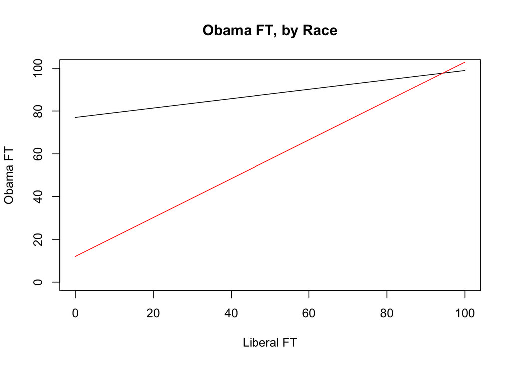

```r
plot(x=0:100,y=yhat_Black,type="l",ylim=c(0,100),
     ylab="Obama FT",xlab="Liberal FT",
     main="Obama FT, by Race")
lines(x=0:100,y=yhat_notBlack,col="red")
```

We can also make predictions, just as we learned above:

```r
predict(m1,newdata=data.frame(black=0,liberalsFT=50))
```

```
##        1
## 57.44902
```

```r
predict(m1,newdata=data.frame(black=0,liberalsFT=51))
```

```
##        1
## 58.35705
```

```r
predict(m1,newdata=data.frame(black=1,liberalsFT=50))
```

```
##        1
## 87.96804
```

```r
predict(m1,newdata=data.frame(black=1,liberalsFT=51))
```

```
##        1
## 88.18746
```

## **How Do I Do This For Logit?**

Remember that we run a logistic regression when we have a dependent variable that has two categories (0 and 1). We run our logistic regression using the `glm()` command and a `family=binomial` argument:

```r
m <- glm(voteObama2012~democrat,anes,family=binomial)
summary(m)
```

```
##
## Call:
## glm(formula = voteObama2012 ~ democrat, family = binomial, data = anes)
##
## Deviance Residuals:
##     Min       1Q   Median       3Q      Max
## -1.9686  -0.7894   0.5577   0.5577   1.6235
##
## Coefficients:
##             Estimate Std. Error z value Pr(>|z|)
## (Intercept) -1.00640    0.04358  -23.09   <2e-16 ***
## democrat     2.78845    0.07672   36.34   <2e-16 ***
## ---
## Signif. codes:  0 '***' 0.001 '**' 0.01 '*' 0.05 '.' 0.1 ' ' 1
##
## (Dispersion parameter for binomial family taken to be 1)
##
##     Null deviance: 6534.8  on 4719  degrees of freedom
## Residual deviance: 4797.9  on 4718  degrees of freedom
##   (1194 observations deleted due to missingness)
## AIC: 4801.9
##
## Number of Fisher Scoring iterations: 4
```

Our predictions from a logit are *predicted probabilities*. They range from 0 to 1. We can calculate predicted probabilities using our formula. This, using our regression coefficients from above, is the predicted probability someone votes for Obama in 2012 if he is a democrat (`democrat=1`)

```r
exp(-1.00640+2.78845*1)/(1+exp(-1.00640+2.78845*1))
```

```
## [1] 0.8559498
```

Or we can have R do it automatically with the `predict()` command. The formula is exactly the same as it was for a linear regression, except we *must* add `type="response"` to the end:

```r
predict(m,newdata=data.frame(democrat=1),type="response")
```

```
##         1
## 0.8559489
```

This also works exactly the same for multivariate logistic regression:

```r
m1 <- glm(voteObama2012~democrat+black+education+age+income,anes,family=binomial)
summary(m1)
```

```
##
## Call:
## glm(formula = voteObama2012 ~ democrat + black + education +
##     age + income, family = binomial, data = anes)
##
## Deviance Residuals:
##     Min       1Q   Median       3Q      Max
## -2.7160  -0.7327   0.2539   0.6647   1.9517
##
## Coefficients:
##              Estimate Std. Error z value Pr(>|z|)
## (Intercept) -1.299238   0.182039  -7.137 9.53e-13 ***
## democrat     2.609762   0.084235  30.982  < 2e-16 ***
## black        1.815951   0.134574  13.494  < 2e-16 ***
## education    0.148372   0.037583   3.948 7.88e-05 ***
## age         -0.005358   0.002414  -2.220   0.0264 *
## income      -0.006483   0.005329  -1.217   0.2237
## ---
## Signif. codes:  0 '***' 0.001 '**' 0.01 '*' 0.05 '.' 0.1 ' ' 1
##
## (Dispersion parameter for binomial family taken to be 1)
##
##     Null deviance: 5966.2  on 4306  degrees of freedom
## Residual deviance: 4086.9  on 4301  degrees of freedom
##   (1607 observations deleted due to missingness)
## AIC: 4098.9
##
## Number of Fisher Scoring iterations: 5
```

Make a predicted probability. Remember to include values for *every independent variable*:

```r
predict(m1,newdata=data.frame(democrat=1,black=1,education=4,age=12,income=3),type="response")
```

```
##         1
## 0.9743248
```

We can use this command to make several predicted probabilities and display them with a barplot:

```r
m2 <- glm(voteObama2012~democrat+republican+black+education+age+income,anes,family=binomial)
summary(m2)
```

```
##
## Call:
## glm(formula = voteObama2012 ~ democrat + republican + black +
##     education + age + income, family = binomial, data = anes)
##
## Deviance Residuals:
##     Min       1Q   Median       3Q      Max
## -2.6458  -0.3886   0.2793   0.6574   2.6028
##
## Coefficients:
##              Estimate Std. Error z value Pr(>|z|)
## (Intercept) -0.524173   0.192964  -2.716 0.006599 **
## democrat     1.872310   0.090149  20.769  < 2e-16 ***
## republican  -2.382105   0.137018 -17.385  < 2e-16 ***
## black        1.613932   0.139234  11.592  < 2e-16 ***
## education    0.135503   0.039645   3.418 0.000631 ***
## age         -0.006217   0.002580  -2.410 0.015973 *
## income      -0.001332   0.005669  -0.235 0.814235
## ---
## Signif. codes:  0 '***' 0.001 '**' 0.01 '*' 0.05 '.' 0.1 ' ' 1
##
## (Dispersion parameter for binomial family taken to be 1)
##
##     Null deviance: 5966.2  on 4306  degrees of freedom
## Residual deviance: 3651.1  on 4300  degrees of freedom
##   (1607 observations deleted due to missingness)
## AIC: 3665.1
##
## Number of Fisher Scoring iterations: 5
```

```r
predict(m2,newdata=data.frame(democrat=1,republican=0,black=0,education=median(anes$education,na.rm=TRUE),
        age=median(anes$age,na.rm=TRUE),income=median(anes$income,na.rm=TRUE)),type="response")
```

```
##         1
## 0.8053783
```

```r
predict(m2,newdata=data.frame(democrat=0,republican=0,black=0,education=median(anes$education,na.rm=TRUE),
        age=median(anes$age,na.rm=TRUE),income=median(anes$income,na.rm=TRUE)),type="response")
```

```
##         1
## 0.3888721
```

```r
predict(m2,newdata=data.frame(democrat=0,republican=1,black=0,education=median(anes$education,na.rm=TRUE),
        age=median(anes$age,na.rm=TRUE),income=median(anes$income,na.rm=TRUE)),type="response")
```

```
##          1
## 0.05550585
```

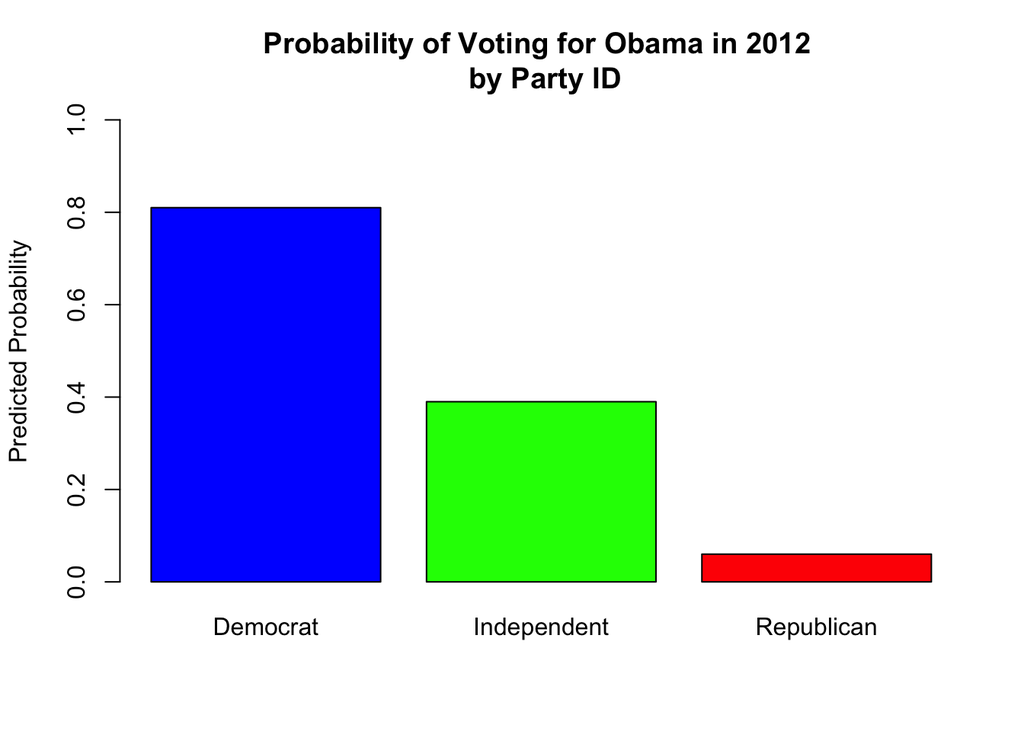

```r
barplot(c(.81,.39,.06),names=c("Democrat","Independent","Republican"), main="Probability of Voting for Obama in 2012 \n by Party ID",
        ylab="Predicted Probability",ylim=c(0,1),col=c("blue","green","red"))
```